# RIDER Experiment 1

Frieda Born

2024-06-10

This document provides an the statistical tests provided in the paper ordered along the sub sections of our publication. We investigate how testing and (de)prioritization during **Working** **Memory** influences how well something sticks to **Long-term** **Memory**. In the following you find the results for *RIDER1*. There are separate documents proving the statistical tests for Exp. 2 & Exp.. 3.

Please note: This markdown document entails the data processing steppwds 1) Trial selection, 2) accuracy calculation (Error °), 3) exp. condition definition, 4) consistency data checks, 5) pruning 6) Calculation of LTM bias by WM Report These steps are not printed in the document, but run in the background when the script runs.

In the following, we are adding (signed) error distribution histograms across WM and LTM (sample/report).

```
## [1] "In response to reviwer comments, in the following, we are showing (signed) error distributions in WM and LTM"
```

```
## [1] "Histogram for WM errors"
```

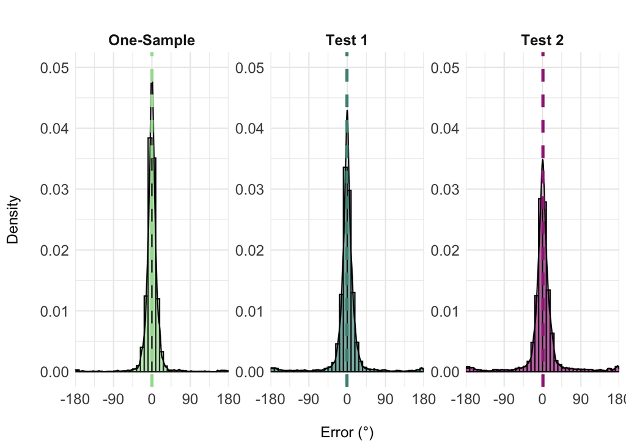

```
## [1] "Histogram for LTM errors"
```

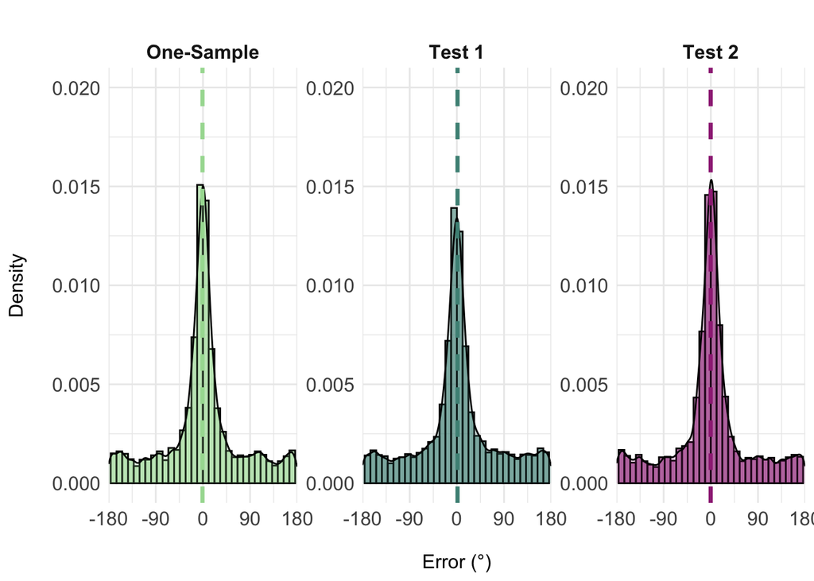

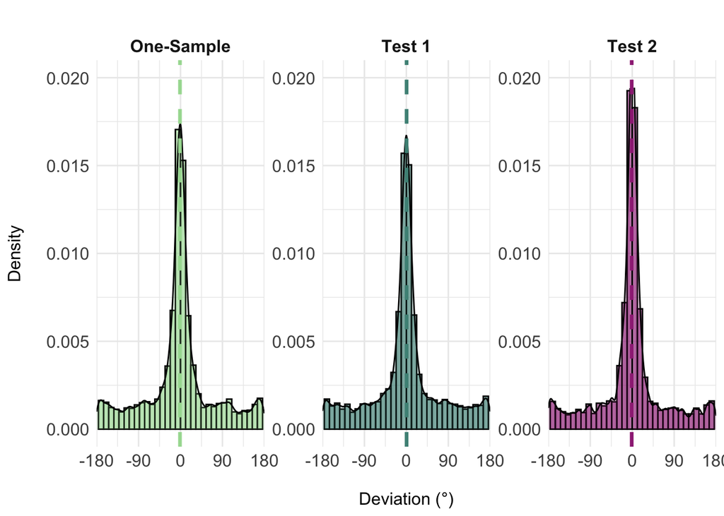

[output not shown]

# Statistics

### **WM Performance**

#### pairwise comparisons and average accuracy across conditions

```
## [1] "This table shows the 3 main pairwise comparisons across the WM exp. conditions"
```

```
## [1] "Please also note that, as requested during revision, we have added the effect sizes (Cohen’s d) to our t-test results tables"
```

| estimate | .y. | group1 | group2 | n1.x | n2.x | statistic | p | df | conf.low | conf.high | method | alternative | p.adj | p.adj.signif | effsize | n1.y | n2.y | magnitude |
| --- | --- | --- | --- | --- | --- | --- | --- | --- | --- | --- | --- | --- | --- | --- | --- | --- | --- | --- |
| 4.410182 | mean | Test 2 | Test 1 | 187 | 187 | 6.503261 | 7.05e-10 | 186 | 3.072329 | 5.748035 | T-test | two.sided | 7.05e-10 | **** | 0.4755655 | 187 | 187 | small |
| 10.310984 | mean | Test 2 | Baseline | 187 | 187 | 13.335209 | 6.62e-29 | 186 | 8.785585 | 11.836383 | T-test | two.sided | 1.99e-28 | **** | 0.9751671 | 187 | 187 | large |
| 5.900802 | mean | Test 1 | Baseline | 187 | 187 | 12.045361 | 4.49e-25 | 186 | 4.934363 | 6.867241 | T-test | two.sided | 8.98e-25 | **** | 0.8808440 | 187 | 187 | large |

```
## [1] "This test shows difference between one sample (1) and two-sample (2) trials (averaged Test1/Test2"
```

| estimate | .y. | group1 | group2 | n1.x | n2.x | statistic | p | df | conf.low | conf.high | method | alternative | p.adj | p.adj.signif | effsize | n1.y | n2.y | magnitude |
| --- | --- | --- | --- | --- | --- | --- | --- | --- | --- | --- | --- | --- | --- | --- | --- | --- | --- | --- |
| -7.367193 | mean | 1 | 2 | 187 | 187 | -14.5297 | 1.85e-32 | 186 | -8.367489 | -6.366897 | T-test | two.sided | 1.85e-32 | **** | -1.062517 | 187 | 187 | large |

```
## [1] "Average WM performance across exp. conditions:"
```

| trial_type_new | N | accuracy | sd | se | ci |
| --- | --- | --- | --- | --- | --- |
| Baseline | 187 | 10.05041 | 6.741155 | 0.4929621 | 0.9725157 |
| Test 1 | 187 | 15.95114 | 9.726002 | 0.7112357 | 1.4031259 |
| Test 2 | 187 | 20.36133 | 13.149546 | 0.9615900 | 1.8970249 |

```
## [1] "Average WM performance acorss one-sample (1) vs. two-sample (2) trials "
```

| sample_trials | N | accuracy | sd | se | ci |
| --- | --- | --- | --- | --- | --- |
| 1 | 187 | 10.05041 | 6.741155 | 0.4929621 | 0.9725157 |
| 2 | 187 | 17.41756 | 10.079340 | 0.7370743 | 1.4541003 |

### ANOVA Results WM

#### (2 x 2 ANOVA Test (1/2) and Sample (1/2)

```
## [1] "This 2 x 2 ANOVA focuses on the priority and sample position effects in the WM task (1/2 sample, 1/2 test)"
```

|  | Effect | DFn | DFd | F | p | p<.05 | ges |
| --- | --- | --- | --- | --- | --- | --- | --- |
| 1 | stimulus_presentation | 1 | 186 | 4.836 | 2.90e-02 | * | 0.003 |
| 2 | exp_condition | 1 | 186 | 39.358 | 2.41e-09 | * | 0.026 |
| 3 | stimulus_presentation:exp_condition | 1 | 186 | 11.369 | 9.08e-04 | * | 0.007 |

|  | Parameter | Eta2_partial | CI | CI_low | CI_high |
| --- | --- | --- | --- | --- | --- |
| 2 | stimulus_presentation | 0.025 | 0.95 | 0.001 | 1.000 |
| 1 | exp_condition | 0.175 | 0.95 | 0.100 | 1.000 |
| 3 | stimulus_presentation:exp_condition | 0.058 | 0.95 | 0.015 | 1.000 |

#### Post-hoc testing for 2 x 2 ANOVA

|  | exp_condition | estimate | .y. | group1 | group2 | n1 | n2 | statistic | p | df | conf.low | conf.high | method | alternative | p.adj | p.adj.signif |
| --- | --- | --- | --- | --- | --- | --- | --- | --- | --- | --- | --- | --- | --- | --- | --- | --- |
| 1 | Test1 | 0.8229572 | mean | Img1 | Img2 | 187 | 187 | 1.207941 | 0.229 | 186 | -0.5210904 | 2.167005 | T-test | two.sided | 0.229 | ns |
| 2 | Test2 | -3.7471979 | mean | Img1 | Img2 | 187 | 187 | -3.238777 | 0.001 | 186 | -6.0296866 | -1.464709 | T-test | two.sided | 0.001 | ** |

```
## [1] "The following table shows the sample 1 /2 effects in WM Test 1 vs. Test 2; including effect size "
```

| exp_condition | estimate | .y. | group1 | group2 | n1.x | n2.x | statistic | p | df | conf.low | conf.high | method | alternative | p.adj | p.adj.signif | effsize | n1.y | n2.y | magnitude |
| --- | --- | --- | --- | --- | --- | --- | --- | --- | --- | --- | --- | --- | --- | --- | --- | --- | --- | --- | --- |
| Test1 | 0.8229572 | mean | Img1 | Img2 | 187 | 187 | 1.207941 | 0.229 | 186 | -0.5210904 | 2.167005 | T-test | two.sided | 0.229 | ns | 0.08833339 | 187 | 187 | negligible |
| Test2 | -3.7471979 | mean | Img1 | Img2 | 187 | 187 | -3.238777 | 0.001 | 186 | -6.0296866 | -1.464709 | T-test | two.sided | 0.001 | ** | -0.23684284 | 187 | 187 | small |

```
## [1] "The following comparisons, additionally, indicate sig. diff. when comparing Sample 1/2 in Test1/2"
```

| .y. | group1 | group2 | n1 | n2 | statistic | df | p | p.adj | p.adj.signif | sample |
| --- | --- | --- | --- | --- | --- | --- | --- | --- | --- | --- |
| mean | Test1 | Test2 | 187 | 187 | -2.293801 | 186 | 0.023 | 0.023 | * | Sample 1 |

| .y. | group1 | group2 | effsize | n1 | n2 | magnitude | sample |
| --- | --- | --- | --- | --- | --- | --- | --- |
| mean | Test1 | Test2 | -0.1677393 | 187 | 187 | negligible | Sample 1 |

| .y. | group1 | group2 | n1 | n2 | statistic | df | p | p.adj | p.adj.signif | sample |
| --- | --- | --- | --- | --- | --- | --- | --- | --- | --- | --- |
| mean | Test1 | Test2 | 187 | 187 | -6.403377 | 186 | 1.21e-09 | 1.21e-09 | **** | Sample 2 |

| .y. | group1 | group2 | effsize | n1 | n2 | magnitude | sample |
| --- | --- | --- | --- | --- | --- | --- | --- |
| mean | Test1 | Test2 | -0.4682613 | 187 | 187 | small | Sample 2 |

```
## [1] "Overview of Average WM performance across sample positions"
```

| image_presentation | N | accuracy | sd | se | ci |
| --- | --- | --- | --- | --- | --- |
| Baseline | 187 | 10.05041 | 6.741155 | 0.4929621 | 0.9725157 |
| Img1-Test1 | 187 | 16.34687 | 10.605319 | 0.7755377 | 1.5299810 |
| Img1-Test2 | 187 | 18.40589 | 14.414224 | 1.0540724 | 2.0794742 |
| Img2-Test1 | 187 | 15.52392 | 10.753221 | 0.7863534 | 1.5513180 |
| Img2-Test2 | 187 | 22.15309 | 16.238711 | 1.1874922 | 2.3426847 |

### **LTM Performance**

#### pairwise comparisons and average accuracy across conditions

```
## [1] "The mean accuracy in the LTM is lower than in the WM task"
```

```
## [1] "Mean: 53.9518448322847"
```

```
## [1] "Standard Error: 1.13723058906211"
```

```
##
##  Paired t-test
##
## data:  mean_performance_LTM$accuracy_ltm and mean_performnce_WM$accuracy
## t = 37.28, df = 186, p-value < 2.2e-16
## alternative hypothesis: true mean difference is not equal to 0
## 95 percent confidence interval:
##  36.37346 40.43825
## sample estimates:
## mean difference
##        38.40586
```

```
## Cohen's d (paired): 2.726
```

```
## [1] "Avergae mean performance across LTM conditions"
```

| trial_type | N | accuracy_ltm | sd | se | ci |
| --- | --- | --- | --- | --- | --- |
| Baseline | 187 | 50.72592 | 18.70922 | 1.368154 | 2.699093 |
| Never tested | 187 | 62.15896 | 19.45166 | 1.422447 | 2.806203 |
| Test 1 | 187 | 53.95696 | 16.73118 | 1.223505 | 2.413731 |
| Test 2 | 187 | 49.00038 | 20.16803 | 1.474833 | 2.909550 |

```
## [1] "This table shows the 3 main pairwise comparisons across the LTM exp. conditions"
```

| estimate | .y. | group1 | group2 | n1.x | n2.x | statistic | p | df | conf.low | conf.high | method | alternative | p.adj | p.adj.signif | effsize | n1.y | n2.y | magnitude |
| --- | --- | --- | --- | --- | --- | --- | --- | --- | --- | --- | --- | --- | --- | --- | --- | --- | --- | --- |
| -3.231037 | mean | Baseline | Test 1 | 187 | 187 | -2.923448 | 4.00e-03 | 186 | -5.4114051 | -1.050670 | T-test | two.sided | 8.00e-03 | ** | -0.2137837 | 187 | 187 | small |
| 1.725545 | mean | Baseline | Test 2 | 187 | 187 | 1.373838 | 1.71e-01 | 186 | -0.7522987 | 4.203390 | T-test | two.sided | 1.71e-01 | ns | 0.1004650 | 187 | 187 | negligible |
| 4.956583 | mean | Test 1 | Test 2 | 187 | 187 | 4.319244 | 2.54e-05 | 186 | 2.6926806 | 7.220485 | T-test | two.sided | 7.62e-05 | **** | 0.3158544 | 187 | 187 | small |

```
## [1] "Here shown average difference between one-sample and two-sample in LTM"
```

| estimate | .y. | group1 | group2 | n1.x | n2.x | statistic | p | df | conf.low | conf.high | method | alternative | p.adj | p.adj.signif | effsize | n1.y | n2.y | magnitude |
| --- | --- | --- | --- | --- | --- | --- | --- | --- | --- | --- | --- | --- | --- | --- | --- | --- | --- | --- |
| -1.579914 | mean | 1 | 2 | 187 | 187 | -1.544111 | 1.24e-01 | 186 | -3.598459 | 0.4386297 | T-test | two.sided | 1.24e-01 | ns | -0.1129165 | 187 | 187 | negligible |
| -11.433075 | mean | 1 | 3 | 187 | 187 | -8.594276 | 3.37e-15 | 186 | -14.057516 | -8.8086337 | T-test | two.sided | 6.74e-15 | **** | -0.6284757 | 187 | 187 | moderate |
| -9.853160 | mean | 2 | 3 | 187 | 187 | -8.799974 | 9.30e-16 | 186 | -12.062067 | -7.6442542 | T-test | two.sided | 2.79e-15 | **** | -0.6435178 | 187 | 187 | moderate |

| sample_trials | N | mean | sd | se | ci |
| --- | --- | --- | --- | --- | --- |
| 1 | 187 | 50.72592 | 18.70919 | 1.368152 | 2.699090 |
| 2 | 187 | 52.30583 | 16.35771 | 1.196194 | 2.359852 |
| 3 | 187 | 62.15899 | 19.45167 | 1.422447 | 2.806204 |

```
## [1] "Here shown are the t-tests for the different distances"
```

```
## Sample 2 (Test 1) vs Baseline: t(186) = 5.51, p = 0.000, d = 0.403 [0.254, 0.552]
```

```
## Sample 1 (Test 2) vs Baseline: t(186) = -3.13, p = 0.002, d = -0.229 [-0.374, -0.083]
```

```
## Recency control (Test-1 followed vs. not followed): t(186) = 1.43, p = 0.155, d = 0.104 [-0.039, 0.248]
```

### ANOVA Results LTM

#### (2 x 2 ANOVA Test (1/2) and Sample (1/2)

```
## [1] "This 2 x 2 ANOVA focuses on the priority and sample position effects in the LTM task (1/2 sample, 1/2 test)"
```

|  | Effect | DFn | DFd | F | p | p<.05 | ges |
| --- | --- | --- | --- | --- | --- | --- | --- |
| 1 | stimulus_presentation | 1 | 186 | 35.805 | 1.10e-08 | * | 0.02600 |
| 2 | exp_condition | 1 | 186 | 20.253 | 1.19e-05 | * | 0.01500 |
| 3 | stimulus_presentation:exp_condition | 1 | 186 | 0.619 | 4.33e-01 |  | 0.00037 |

|  | Parameter | Eta2_partial | CI | CI_low | CI_high |
| --- | --- | --- | --- | --- | --- |
| 2 | stimulus_presentation | 0.161426582 | 0.95 | 0.08866731 | 1 |
| 1 | exp_condition | 0.098192805 | 0.95 | 0.04059655 | 1 |
| 3 | stimulus_presentation:exp_condition | 0.003315418 | 0.95 | 0.00000000 | 1 |

```
## [1] "These post-hoc comparisons show the difference of sample position in Test 1 and Test 2(*)"
```

| exp_condition | estimate | .y. | group1 | group2 | n1.x | n2.x | statistic | p | df | conf.low | conf.high | method | alternative | p.adj | p.adj.signif | effsize | n1.y | n2.y | magnitude |
| --- | --- | --- | --- | --- | --- | --- | --- | --- | --- | --- | --- | --- | --- | --- | --- | --- | --- | --- | --- |
| Test1 | -7.951401 | mean | Img1 | Img2 | 187 | 187 | -5.909222 | 1.61e-08 | 186 | -10.605985 | -5.296817 | T-test | two.sided | 1.61e-08 | **** | -0.4321251 | 187 | 187 | small |
| Test2 | -6.290299 | mean | Img1 | Img2 | 187 | 187 | -3.488400 | 6.06e-04 | 186 | -9.847662 | -2.732937 | T-test | two.sided | 6.06e-04 | *** | -0.2550971 | 187 | 187 | small |

#### Comparison tested and not probed (NP) items in LTM

```
## [1] "This table shows the 3 main pairwise comparisons across the LTM exp. conditions vs. not probed"
```

| estimate | .y. | group1 | group2 | n1.x | n2.x | statistic | p | df | conf.low | conf.high | method | alternative | p.adj | p.adj.signif | effsize | n1.y | n2.y | magnitude |
| --- | --- | --- | --- | --- | --- | --- | --- | --- | --- | --- | --- | --- | --- | --- | --- | --- | --- | --- |
| -11.433075 | mean | Baseline | Never tested | 187 | 187 | -8.594276 | 3.37e-15 | 186 | -14.0575161 | -8.808634 | T-test | two.sided | 1.68e-14 | **** | -0.6284757 | 187 | 187 | moderate |
| -3.231037 | mean | Baseline | Test 1 | 187 | 187 | -2.923448 | 4.00e-03 | 186 | -5.4114051 | -1.050670 | T-test | two.sided | 8.00e-03 | ** | -0.2137837 | 187 | 187 | small |
| 1.725545 | mean | Baseline | Test 2 | 187 | 187 | 1.373838 | 1.71e-01 | 186 | -0.7522987 | 4.203390 | T-test | two.sided | 1.71e-01 | ns | 0.1004650 | 187 | 187 | negligible |
| 8.202037 | mean | Never tested | Test 1 | 187 | 187 | 6.908099 | 7.56e-11 | 186 | 5.8597172 | 10.544358 | T-test | two.sided | 3.02e-10 | **** | 0.5051702 | 187 | 187 | moderate |
| 13.158620 | mean | Never tested | Test 2 | 187 | 187 | 9.745562 | 2.17e-18 | 186 | 10.4949126 | 15.822328 | T-test | two.sided | 1.30e-17 | **** | 0.7126661 | 187 | 187 | moderate |
| 4.956583 | mean | Test 1 | Test 2 | 187 | 187 | 4.319244 | 2.54e-05 | 186 | 2.6926806 | 7.220485 | T-test | two.sided | 7.62e-05 | **** | 0.3158544 | 187 | 187 | small |

```
## [1] "Here shown is the primacy effect also in the NP condition"
```

| estimate | .y. | group1 | group2 | n1.x | n2.x | statistic | p | df | conf.low | conf.high | method | alternative | p.adj | p.adj.signif | effsize | n1.y | n2.y | magnitude |
| --- | --- | --- | --- | --- | --- | --- | --- | --- | --- | --- | --- | --- | --- | --- | --- | --- | --- | --- |
| -6.105307 | accuracy | Img1-NT | Img2-NT | 187 | 187 | -3.308149 | 0.001 | 186 | -9.746181 | -2.464434 | T-test | two.sided | 0.001 | ** | -0.2419158 | 187 | 187 | small |

### **Comparison WM and LTM**

#### Comparing WM vs. LTM performance

#### ANOVA Results (2 x 2 x 2 ANOVA Test (1/2) and Sample (1/2) and task (WM/LTM)

|  | Effect | DFn | DFd | F | p | p<.05 | ges |
| --- | --- | --- | --- | --- | --- | --- | --- |
| 1 | stimulus_presentation | 1 | 186 | 35.085 | 1.50e-08 | * | 0.014000 |
| 2 | exp_condition | 1 | 186 | 0.342 | 5.60e-01 |  | 0.000157 |
| 3 | task | 1 | 186 | 970.059 | 1.03e-75 | * | 0.468000 |
| 4 | stimulus_presentation:exp_condition | 1 | 186 | 1.132 | 2.89e-01 |  | 0.000413 |
| 5 | stimulus_presentation:task | 1 | 186 | 19.805 | 1.47e-05 | * | 0.006000 |
| 6 | exp_condition:task | 1 | 186 | 69.396 | 1.73e-14 | * | 0.018000 |
| 7 | stimulus_presentation:exp_condition:task | 1 | 186 | 7.589 | 6.00e-03 | * | 0.002000 |

|  | Parameter | Eta2_partial | CI | CI_low | CI_high |
| --- | --- | --- | --- | --- | --- |
| 2 | exp_condition:task | 0.272 | 0.95 | 0.186 | 1.000 |
| 6 | stimulus_presentation:task | 0.096 | 0.95 | 0.039 | 1.000 |
| 1 | exp_condition | 0.002 | 0.95 | 0.000 | 1.000 |
| 4 | stimulus_presentation:exp_condition | 0.006 | 0.95 | 0.000 | 1.000 |
| 7 | task | 0.839 | 0.95 | 0.808 | 1.000 |
| 5 | stimulus_presentation:exp_condition:task | 0.039 | 0.95 | 0.006 | 1.000 |
| 3 | stimulus_presentation | 0.159 | 0.95 | 0.086 | 1.000 |

### **Pruning for equivalent WM performance**

#### pairwise comparisons and average performances across conditions

```
## [1] "Pairwise comparisons of pruned data exp. conditions"
```

| estimate | .y. | group1 | group2 | n1.x | n2.x | statistic | p | df | conf.low | conf.high | method | alternative | p.adj | p.adj.signif | effsize | n1.y | n2.y | magnitude |
| --- | --- | --- | --- | --- | --- | --- | --- | --- | --- | --- | --- | --- | --- | --- | --- | --- | --- | --- |
| -2.732390 | mean | Baseline | Test 1 | 187 | 187 | -2.479314 | 1.40e-02 | 186 | -4.906564 | -0.5582163 | T-test | two.sided | 1.40e-02 | * | -0.1813054 | 187 | 187 | negligible |
| 4.365289 | mean | Baseline | Test 2 | 187 | 187 | 3.509633 | 5.63e-04 | 186 | 1.911516 | 6.8190619 | T-test | two.sided | 1.00e-03 | ** | 0.2566498 | 187 | 187 | small |
| 7.097679 | mean | Test 1 | Test 2 | 187 | 187 | 6.333566 | 1.75e-09 | 186 | 4.886871 | 9.3084878 | T-test | two.sided | 5.25e-09 | **** | 0.4631562 | 187 | 187 | small |

```
## [1] "Avergae performances in pruned data"
```

| exp_condition | N | mean | sd | se | ci |
| --- | --- | --- | --- | --- | --- |
| Baseline | 187 | 50.68119 | 18.72172 | 1.369068 | 2.700897 |
| Test 1 | 187 | 53.41358 | 16.88002 | 1.234389 | 2.435204 |
| Test 2 | 187 | 46.31590 | 19.96372 | 1.459892 | 2.880075 |

### **LTM recall of WM sample vs. WM report**

#### Pairwise comparisons of WM sample vs report and 2 x 3 repeated measures ANOVA

```
## [1] "Here shown are the pairwise comparisons for LTM accuracy of WM Report (instead of sample)"
```

|  | estimate | .y. | group1 | group2 | n1 | n2 | statistic | p | df | conf.low | conf.high | method | alternative | p.adj | p.adj.signif |
| --- | --- | --- | --- | --- | --- | --- | --- | --- | --- | --- | --- | --- | --- | --- | --- |
| 1 | -2.287583 | mean | Baseline | Test 1 | 187 | 187 | -2.052688 | 4.20e-02 | 186 | -4.486136 | -0.08902928 | T-test | two.sided | 4.20e-02 | * |
| 2 | 5.885299 | mean | Baseline | Test 2 | 187 | 187 | 4.314241 | 2.60e-05 | 186 | 3.194092 | 8.57650717 | T-test | two.sided | 5.20e-05 | **** |
| 3 | 8.172882 | mean | Test 1 | Test 2 | 187 | 187 | 7.183882 | 1.58e-11 | 186 | 5.928488 | 10.41727650 | T-test | two.sided | 4.74e-11 | **** |

```
## [1] "Here shown is the pairwise comparison of LTM accuracy Sample vs. Report"
```

```
## t(186) = 10.77, p = 0.000, Cohen's d = 0.788
```

| exp_condition | estimate | .y. | group1 | group2 | n1.x | n2.x | statistic | p | df | conf.low | conf.high | method | alternative | p.adj | p.adj.signif | effsize | n1.y | n2.y | magnitude |
| --- | --- | --- | --- | --- | --- | --- | --- | --- | --- | --- | --- | --- | --- | --- | --- | --- | --- | --- | --- |
| Baseline | -1.075032 | mean | Report | Sample | 187 | 187 | -3.424146 | 7.59e-04 | 186 | -1.694405 | -0.4556592 | T-test | two.sided | 7.59e-04 | *** | -0.2503984 | 187 | 187 | small |
| Test 1 | -2.018487 | mean | Report | Sample | 187 | 187 | -6.101093 | 5.98e-09 | 186 | -2.671168 | -1.3658051 | T-test | two.sided | 5.98e-09 | **** | -0.4461561 | 187 | 187 | small |
| Test 2 | -5.234786 | mean | Report | Sample | 187 | 187 | -8.709002 | 1.65e-15 | 186 | -6.420592 | -4.0489801 | T-test | two.sided | 1.65e-15 | **** | -0.6368653 | 187 | 187 | moderate |

|  | Effect | DFn | DFd | F | p | p<.05 | ges |
| --- | --- | --- | --- | --- | --- | --- | --- |
| 1 | exp_condition | 1.91 | 356.00 | 16.404 | 2.53e-07 | * | 0.020 |
| 2 | type | 1.00 | 186.00 | 120.079 | 7.05e-22 | * | 0.005 |
| 3 | exp_condition:type | 1.62 | 301.17 | 25.248 | 2.35e-09 | * | 0.002 |

```
## # Effect Size for ANOVA (Type III)
##
## Parameter          | Eta2 (partial) |         95% CI
## ----------------------------------------------------
## exp_condition      |          0.081 | [0.040, 1.000]
## type               |          0.392 | [0.306, 1.000]
## exp_condition:type |          0.120 | [0.071, 1.000]
##
## - One-sided CIs: upper bound fixed at [1.000].
```

```
## # A tibble: 2 × 3
##   WM_point  mean_accuracy_ltm se_accuracy_ltm
##   <chr>                 <dbl>           <dbl>
## 1 WM_report              48.5           0.812
## 2 WM_sample              51.2           0.788
```

```
##
##  Paired t-test
##
## data:  summary_df2$WM_sample_accuracy and summary_df2$WM_report_accuracy
## t = 10.958, df = 186, p-value < 2.2e-16
## alternative hypothesis: true mean difference is not equal to 0
## 95 percent confidence interval:
##  2.276291 3.275874
## sample estimates:
## mean difference
##        2.776083
```

```
## ANOVA Table (type III tests)
##
## $ANOVA
##       Effect DFn DFd      F        p p<.05   ges
## 1 trial_type   2 372 25.247 5.23e-11     * 0.082
##
## $`Mauchly's Test for Sphericity`
##       Effect     W        p p<.05
## 1 trial_type 0.765 1.69e-11     *
##
## $`Sphericity Corrections`
##       Effect  GGe       DF[GG]    p[GG] p[GG]<.05   HFe       DF[HF]    p[HF]
## 1 trial_type 0.81 1.62, 301.17 2.35e-09         * 0.816 1.63, 303.43 2.08e-09
##   p[HF]<.05
## 1         *
```

|  | Parameter | Eta2_partial | CI | CI_low | CI_high |
| --- | --- | --- | --- | --- | --- |
| 1 | trial_type | 0.1195152 | 0.95 | 0.07069053 | 1 |

##### Check that LTM reports were not additionally biased by the (random) initial orientations in which the WM probes first appeared on screen

| trial_type | p_value | p_value_adjusted | cohen_d | ci_low | ci_high |
| --- | --- | --- | --- | --- | --- |
| Baseline | 0.62802708 | 1.0000000 | -0.03548943 | 87.81214 | 91.32395 |
| Test 1 | 0.04583906 | 0.1375172 | 0.14701113 | 90.02266 | 92.40389 |
| Test 2 | 0.67461772 | 1.0000000 | 0.03074879 | 88.67437 | 92.04379 |

```
## [1] "The LTM accuracy does not seem to be sig. biased by random WM probe orientations"
```

```
##
##  One Sample t-test
##
## data:  summary_stats_participant_random_probe$accuracy_ltm
## t = 0.83035, df = 560, p-value = 0.4067
## alternative hypothesis: true mean is not equal to 90
## 95 percent confidence interval:
##  89.48092 91.27935
## sample estimates:
## mean of x
##  90.38013
```

In response to a reviewer comment, we are adding the statistical test that concern repulsion bias below

```
##   sample_trials   N     mean       sd       se       ci
## 1             1 187 50.72592 18.70919 1.368152 2.699090
## 2             2 187 52.30583 16.35771 1.196194 2.359852
## 3             3 187 62.15899 19.45167 1.422447 2.806204
```

```
## [1] "These are the results of the repulsion bias we see in Test 1 and Test 2 in WM"
```

```
## [1] "Test 1"
```

[output not shown]

```
## 95% CI: [92.66, 95.18]
```

```
## [1] 0.4467466
```

```
## [1] "Test 2"
```

```
##
##  One Sample t-test
##
## data:  participant_means$mean_error_to_other_t2
## t = 4.4619, df = 187, p-value = 1.401e-05
## alternative hypothesis: true mean is not equal to 90
## 95 percent confidence interval:
##  91.95162 95.04508
## sample estimates:
## mean of x
##  93.49835
```

```
## 95% CI: [91.95, 95.05]
```

```
## [1] 0.3254158
```

```
## [1] "Comparison of Test 1 and Test 2 (WM)"
```

```
##
##  Paired t-test
##
## data:  participant_means$mean_error_to_other_t1 and participant_means$mean_error_to_other_t2
## t = 0.5999, df = 187, p-value = 0.5493
## alternative hypothesis: true mean difference is not equal to 0
## 95 percent confidence interval:
##  -0.963222  1.805039
## sample estimates:
## mean difference
##       0.4209084
```

```
## 95% CI: [-0.96, 1.81]
```

```
## [1] 0.04375216
```

```
##
##  One Sample t-test
##
## data:  data_LTM_joined_filtered$error_to_other_ltm_abs
## t = 6.9526, df = 14367, p-value = 3.742e-12
## alternative hypothesis: true mean is not equal to 90
## 95 percent confidence interval:
##  92.10481 93.75759
## sample estimates:
## mean of x
##   92.9312
```

```
## [1] "These are the results of the repulsion bias we see in Test 1 and Test 2 in LTM"
```

```
## [1] "Test 1"
```

```
##
##  One Sample t-test
##
## data:  participant_means_ltm_by_test$mean_error_to_other_Test.1
## t = 4.3486, df = 186, p-value = 2.254e-05
## alternative hypothesis: true mean is not equal to 90
## 95 percent confidence interval:
##  91.39638 93.71539
## sample estimates:
## mean of x
##  92.55589
```

```
## [1] 0.3180033
```

```
## [1] 0.5877455
```

```
## [1] "Test 2"
```

```
##
##  One Sample t-test
##
## data:  participant_means_ltm_by_test$mean_error_to_other_Test.2
## t = 4.6706, df = 186, p-value = 5.741e-06
## alternative hypothesis: true mean is not equal to 90
## 95 percent confidence interval:
##  92.13448 95.25617
## sample estimates:
## mean of x
##  93.69533
```

```
## [1] 0.341551
```

```
## [1] 0.7911823
```

```
## [1] "Comparison of Test 1 and Test 2"
```

```
##
##  Paired t-test
##
## data:  participant_means_ltm_by_test$mean_error_to_other_Test.1 and participant_means_ltm_by_test$mean_error_to_other_Test.2
## t = -1.2574, df = 186, p-value = 0.2102
## alternative hypothesis: true mean difference is not equal to 0
## 95 percent confidence interval:
##  -2.9271079  0.6482282
## sample estimates:
## mean difference
##        -1.13944
```

```
## [1] -0.09195319
```